```python
from datascience import *
%matplotlib inline
import matplotlib.pyplot as plots
plots.style.use('fivethirtyeight')
import numpy as np
```

# Lecture 21

## Students Flipping Fair Coins Conclude Coin is Unfiar!

We know that we gave all of them fair coints. How often will they incorrectly reject the null hypothesis?

Could you write code to simulate the process of one student running this hypothesis test?

```python
def simulate_one_hypothesis_test():
    num_coin_flips = 100
    # Student Collects Data by actually flipping the coin (we simualte here)
    # its fair coin but we didn't tell the studnet
    obs_flips = np.random.choice(["H", "T"], num_coin_flips)

    # Define the test statistic
    def test_statistic(flips_dataset):
        return ...

    # Compute the observed value of the statistic on our actual data
    obs_statistic = ...

    # Define a function to simulate the statistic under the null hypothesis
    def simulate_one_statistic():
        sim_flips = ...
        sim_statistic = ...
        return sim_statistic

    # Hypothesis Test: Simulate from Null hypothesis
    simulated_statistics = make_array()
    for i in np.arange(1000):  # Simulate 1000 trials
        ...

    # Compute the P Value
    p_value = ...

    return ... # The p-value that the simulated student got
```

Solution below...

### Simulating the Simulation

In the following we will use simulation to simulate the students running a simulation. Very meta!

```python
def simulate_one_hypothesis_test():
    num_coin_flips = 100
    num_simulations = 1000
    # Student Collects Data by actually flipping the coin (we simualte here)
    # its fair coin but we didn't tell the studnet
    obs_flips = np.random.choice(["H", "T"], num_coin_flips)

    # Define the test statistic
    def test_statistic(flips_dataset):
        num_heads = sum(flips_dataset == "H")
        return np.abs(num_heads - 50)

    # Compute the observed value of the statistic on our actual data
    obs_statistic = test_statistic(obs_flips)

    # Define a function to simulate the statistic under the null hypothesis
    def simulate_one_statistic():
        sim_flips = np.random.choice(["H", "T"], num_coin_flips)
        sim_statistic = test_statistic(sim_flips)
        return sim_statistic

    # Hypothesis Test: Simulate from Null hypothesis
    simulated_statistics = make_array()
    for i in np.arange(num_simulations):  # Simulate 1000 trials
        simulated_statistics = np.append(simulated_statistics, simulate_one_statistic())

    # Compute the P Value
    p_value = sum(simulated_statistics >= obs_statistic)/len(simulated_statistics)

    return p_value



simulate_one_hypothesis_test()
```

```
0.76700000000000002
```

Simulate the entire class running the experiment.

```python
all_data8_students = make_array()
for i in np.arange(2000):
    all_data8_students = np.append(all_data8_students, simulate_one_hypothesis_test())
```

You would seldom do this in practice, but here we can visualize the distribution of p-values that all the students in the class get. Some will conclude that they have an unfair coin.

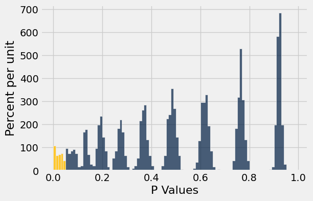

```python
tbl = Table().with_column("P Values", all_data8_students)
tbl.hist("P Values", bins=np.arange(0,1,0.01), right_end=0.05)
```

```python
print(sum(all_data8_students <= 0.05), " would falsely reject the null hypothesis.")
```

```
70  would falsely reject the null hypothesis.
```

## Super Soda Co and the Case of Bad Taste

Manufacturers of Super Soda run a taste test and 91 out of 200 tasters prefer Super Soda over its rival. The boss is upset! He asks:

```
Do fewer people prefer Super Soda, or is this just chance?
```

You run a hypothesis test:

- **Null Hypothesis:** Equal proportions of the population prefer Super Soda as Rival and any variability is due to chance.
- **Alternative Hypothesis:** Fewer people in the population prefer Super Soda than its Rival.
- **Test Statistic:** Number of people who prefer Super Soda

You pick a **p-value cutoff of 0.05**

```python
obs_statistic = 91
```

Simulating the test_statistic from the null hypothesis

```python
def simulate_one_count(sample_size):
    simulated_data = np.random.choice(['Super', 'Rival'], sample_size)
    simulated_statistic = np.count_nonzero(simulated_data == "Super")
    return simulated_statistic
simulate_one_count(200)
```

```
104
```

Running many simulations of the test statistic

```python
num_simulations = 10_000
counts = make_array()
for i in np.arange(num_simulations):
    counts = np.append(counts, simulate_one_count(200))
```

Plotting the distribution of the test statistic under the null hypothesis:

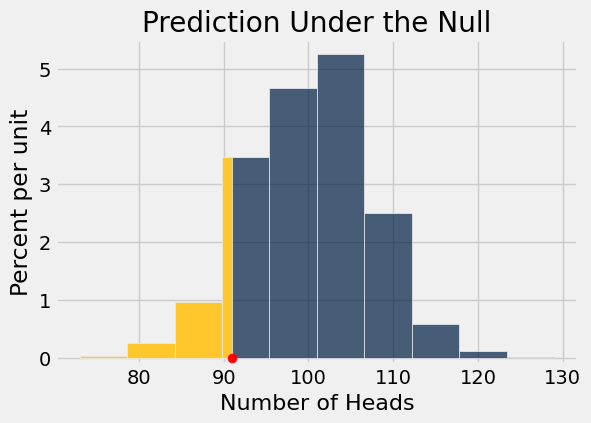

```python
trials = Table().with_column('Number of Heads', counts)
trials.hist(right_end=91)
plots.ylim(-0.001, 0.055)
plots.scatter(91, 0, color='red', s=40, zorder=3)
plots.title('Prediction Under the Null');
```

```python
p_value = np.count_nonzero(counts <= 91)/len(counts)
print("The p-value is", p_value)
```

```
The p-value is 0.117
```

## Changing the number of simulations

What happens if we run a different number of simulations?

```python
# Keeping the data fixed, we can re-run the test with a new simulation under the null
def simulate_null(num_simulations, sample_size):
    counts = make_array()
    for i in np.arange(num_simulations):
        counts = np.append(counts, simulate_one_count(sample_size))
    return counts
```

```python
# Keeping the data fixed, we can re-run the test with a new simulation under the null
def run_test(num_simulations, sample_size, obs_statistic):
    counts = simulate_null(num_simulations, sample_size)
    # compute the p value
    p_value = np.count_nonzero(counts <= obs_statistic)/len(counts)
    return p_value
```

### Simulating the Simulation (Again)

We can again run multiple simulations of our simulation.

```python
# Let's repeat that 50 times for each number of simulations
tests = Table(['simulations', 'p-value for 91'])
for k in np.arange(100): # will run the simulation 100 times
    for num_sims in [100, 1000, 10000]:
        p_value = run_test(num_sims, 200, 91)
        tests = tests.with_row([num_sims, p_value])
tests.show(3)
```

| simulations | p-value for 91 |
| --- | --- |
| 100 | 0.13 |
| 1000 | 0.092 |
| 10000 | 0.1199 |

... (297 rows omitted)

We can then visualize the distribution of p-values. Notice how as we increase the number of simulations the estimate for the p-value concentrates around a single number.

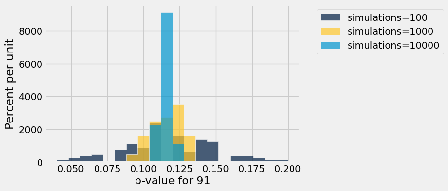

```python
# For larger numbers of simulations, p-values are more consistent
tests.hist("p-value for 91", group='simulations', bins=20)
```

## Law of Large Number

The reason the p-values concentrate towards the true p-value is that the emprical distribution under the null is better approximates by increasing the number of simulations. More is better!

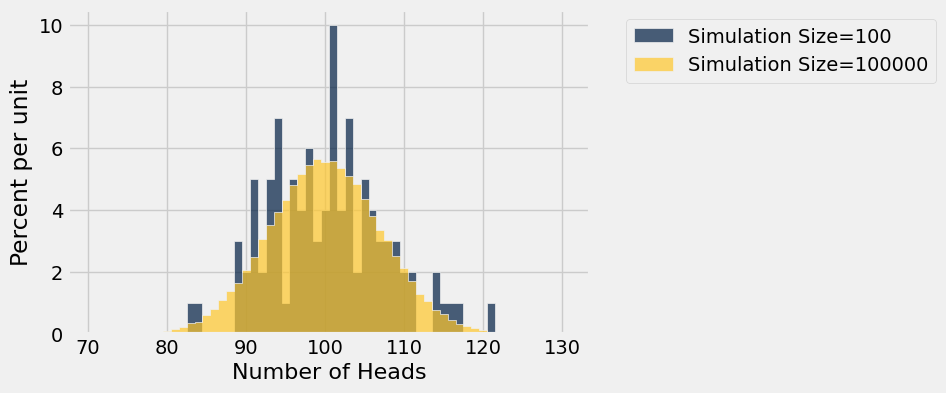

```python
t1 = Table().with_columns("Number of Heads", simulate_null(100, 200),
                           "Simulation Size", 100)
t2 = Table().with_columns("Number of Heads", simulate_null(100_000, 200),
                           "Simulation Size", 100_000)
t1.append(t2).hist(group='Simulation Size', bins=np.arange(70.5, 131, 1))
```

## The Importance of Sample Size

Larger samples give us more information about the population and also allow us to test more subtle differences.

Suppose that the true proportion of people who prefer Super Soda is 45%

```python
true_proportion = 0.45
true_distribution = make_array(true_proportion, 1 - true_proportion)
true_distribution
```

```
array([ 0.45,  0.55])
```

Taste tests with 200 people will give varioius numbers of people who prefer Super Soda

```python
sample_size = 200
sample_proportions(sample_size, true_distribution) * sample_size
```

```
array([  89.,  111.])
```

```python
# If you run a taste test for 200 people, what might you conclude?
def run_experiment(num_simulations, sample_size, true_proportion):
    # Collect data
    true_distribution = make_array(true_proportion, 1 - true_proportion)
    taste_test_results = sample_proportions(sample_size, true_distribution) * sample_size
    observed_stat_from_this_sample = taste_test_results.item(0)

    # Conduct hypothesis test
    p_value = run_test(num_simulations, sample_size, observed_stat_from_this_sample)
    return p_value

run_experiment(10000, 200, 0.45)
```

```
0.3146
```

Try using different values for the true_proportion and sample size. What happens to as the true proportion gets closer to 0.5? What happens if we increase the sample size.

```
Percent that correctly reject the null 27.0
```

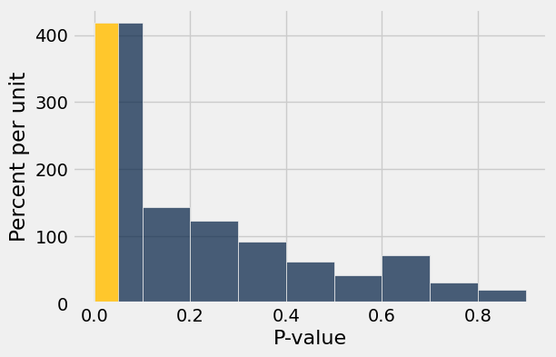

```python
# Let's imagine running our taste test over and over again to see how often we reject the null
true_proportion = 0.45
sample_size = 100
p_values = make_array()
for k in np.arange(100):
    p_value = run_experiment(1000, sample_size, true_proportion)
    p_values = np.append(p_values, p_value)
Table().with_column('P-value', p_values).hist(0, right_end=0.05, bins=np.arange(0,1,0.1))
print("Percent that correctly reject the null", 100*np.mean(p_values <= 0.05))
```